# R Graphics Cookbook

## 12. Using Colors in Plots

### 12.1 Setting the Colors of Objects

> `colour` controls the color of lines and of the outlines of polygons

> `fill` controls the color of the fill area of polygons

> `point shapes` are sometimes a little different. For most point shapes, the color of the entire point is controlled by colour, not fill. The exception is the point shapes (21–25) that have both a fill and an outline.

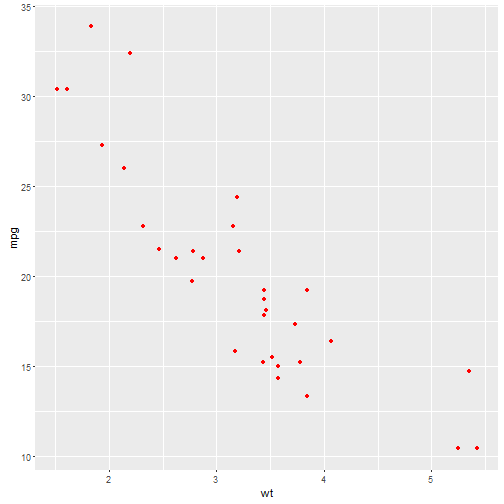

```r
ggplot(data = mtcars, mapping = aes(x = wt, y = mpg)) +
    geom_point(colour = "red")
```

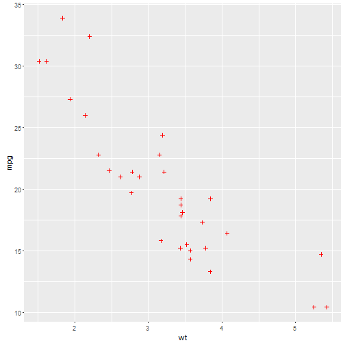

```r
ggplot(data = mtcars, mapping = aes(x = wt, y = mpg)) +
    geom_point(colour = "red", shape = 3)
```

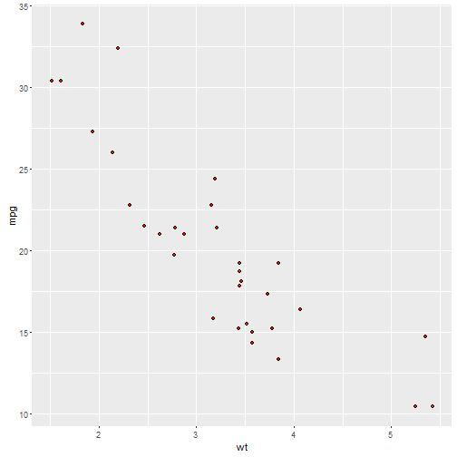

```r
ggplot(data = mtcars, mapping = aes(x = wt, y = mpg)) +
    geom_point(fill = "red", colour = "black", shape = 21)
```

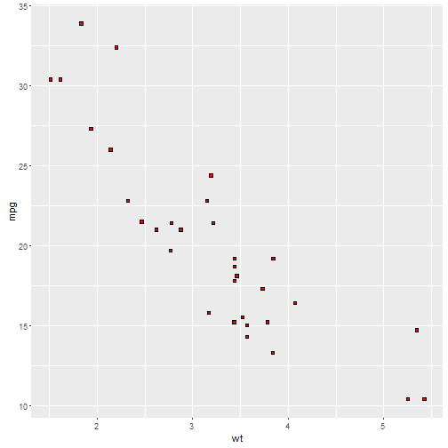

```r
ggplot(data = mtcars, mapping = aes(x = wt, y = mpg)) +
    geom_point(fill = "red", colour = "black", shape = 22)
```

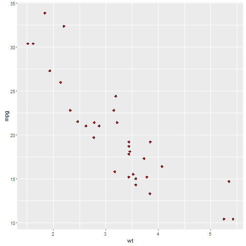

```r
ggplot(data = mtcars, mapping = aes(x = wt, y = mpg)) +
    geom_point(fill = "red", colour = "black", shape = 23)
```

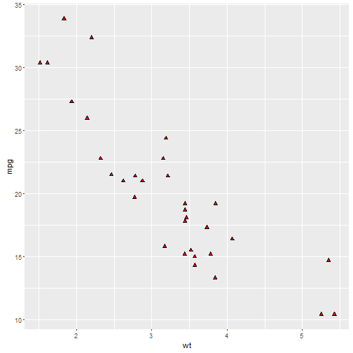

```r
ggplot(data = mtcars, mapping = aes(x = wt, y = mpg)) +
    geom_point(fill = "red", colour = "black", shape = 24)
```

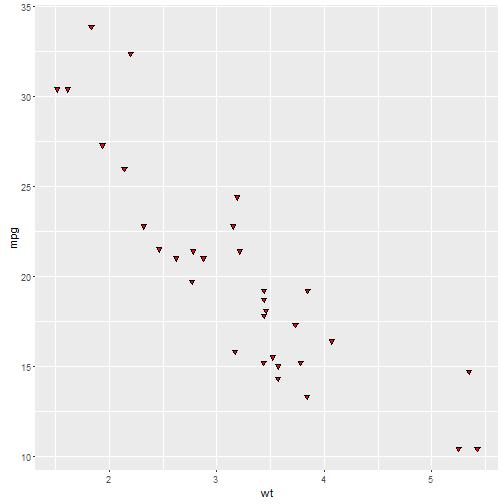

```r
ggplot(data = mtcars, mapping = aes(x = wt, y = mpg)) +
    geom_point(fill = "red", colour = "black", shape = 25)
```

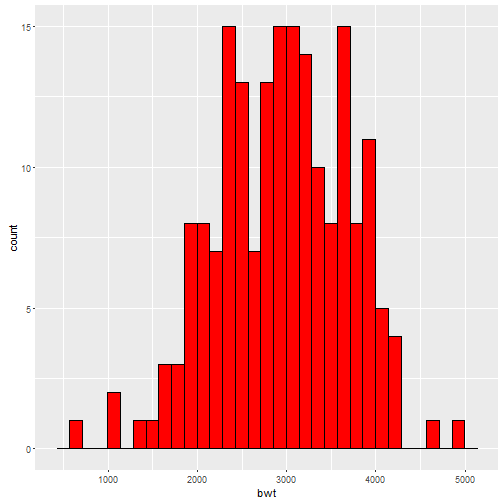

```r
ggplot(data = birthwt, mapping = aes(x = bwt)) +
    geom_histogram(fill = "red", colour = "black")
```

## 12.2 Mapping Variables to Colors

> Use a variable (column from a data frame) to control the color of geoms

> In the call to the geom, set the value of colour or fill to the name of one of the columns in the data

```r
head(cabbage_exp)
```

```
##   Cultivar Date Weight        sd  n         se
## 1      c39  d16   3.18 0.9566144 10 0.30250803
## 2      c39  d20   2.80 0.2788867 10 0.08819171
## 3      c39  d21   2.74 0.9834181 10 0.31098410
## 4      c52  d16   2.26 0.4452215 10 0.14079141
## 5      c52  d20   3.11 0.7908505 10 0.25008887
## 6      c52  d21   1.47 0.2110819 10 0.06674995
```